# REF/ALT allele skew of LCL cCREs and co-accessible pairs

Crystal Shan

# REF/ALT accessibility of LCL cCREs and co-accessible pairs

Single-cCRE tests compare that element’s accessibility between REF and ALT reads. Pair tests compare the fraction of spanning reads with both cCREs open between REF and ALT. A pair difference can arise from one element’s accessibility difference; it does not by itself establish a difference in coordination between the elements.

All four REF/ALT tests use a two-sided Fisher exact test and BH correction. A donor contributes to a cCRE/pair test only when it has **at least 10 REF reads and 10 ALT reads** at the chosen heterozygous SNP (open plus closed reads). The same donor-level rule applies before pooling. Within-donor BH is applied separately for cCREs and pairs; pooled BH is applied across units separately for cCREs and pairs. Positive `diff = ALT fraction - REF fraction` favors ALT. `n_samples_both_alleles` counts donors passing the 10-reads-per-allele rule.

| Unit | Within donor, REF vs ALT | Across donors, REF vs ALT |
| --- | --- | --- |
| cCRE | `LCL_hsca_cre_allele_by_sample` | `LCL_hsca_cre_allele` |
| pair | `LCL_hsca_pair_allele_by_sample` | `LCL_hsca_pair_allele` |

## HSCA test on CRE and CRE pairs

use a 2x2 table with REF and ALT. For a single cCRE, the columns are accessible and not accessible. For a pair, the columns are both cCREs open and not both open, either one open or neither open

- Each donor must have at least 10 reads of each allele for the unit being tested

| Test | Question and null hypothesis | Interpretation of a significant result |
| --- | --- | --- |
| Single cCRE, within donor | Is this cCRE more accessible on REF or ALT reads in this donor? Null: the accessible fraction is equal between alleles. | Accessibility of this element is associated with the focal allele in this donor. |
| cCRE pair, within donor | Are both cCREs open together more often on REF or ALT reads in this donor? Null: the both-open fraction is equal between alleles among reads covering both elements. | Joint accessibility differs between alleles in this donor |
| Single cCRE, pooled across donors | Is this cCRE’s accessible fraction different between REF and ALT after summing eligible donor counts? Null: the pooled accessible fractions are equal. | There is an aggregate allele-associated accessibility difference at this element. |
| cCRE pair, pooled across donors | Is the both-open fraction different between REF and ALT after summing eligible donor counts? Null: the pooled both-open fractions are equal. | There is an aggregate allele-associated difference in joint accessibility of this pair. |

Within-donor tests receive BH correction across tested cCREs or pairs separately in each donor. Pooled tests receive BH correction across tested cCREs or pairs separately

```bash
cd /project/spott/cshan/fiber-seq/code/co-accessibility/LCL/hsca
sbatch LCL_run_hsca.sh
```

VCF file: `/project/spott/1_Shared_projects/LCL_Fiber_seq/preprocess_final_merged_samples/AL6_bc2162_19093/AL6_bc2162_19093.5mC.6mA.aligned.phased.vcf.gz`

| Column | Meaning |
| --- | --- |
| `#CHROM` | Chromosome, such as `chr1`. |
| `POS` | **1-based** genomic position, unlike a BED start coordinate. |
| `ID` | Variant identifier, such as an rsID; `.` means missing. |
| `REF` | Reference allele. |
| `ALT` | Alternative allele(s); multiple alternatives are comma-separated. |
| `QUAL` | Variant-level Phred-scaled quality; `.` means unavailable. |
| `FILTER` | Variant filtering result. `PASS` means it passed the applied filters. |
| `INFO` | Semicolon-separated variant annotations, such as `AF=0.0168067`. |
| `FORMAT` | Colon-separated names defining the fields in each sample’s cell. |
| `NA19093`, other sample names | That sample’s genotype and any additional fields specified by `FORMAT`. |

| `GT` | Interpretation |
| --- | --- |
| `0/0` | Homozygous REF. |
| `0/1` | Heterozygous, unphased. |
| `0\\|1` | Phased: first haplotype carries REF, second carries ALT. |
| `1\\|0` | Phased: first haplotype carries ALT, second carries REF. |
| `1/1` | Homozygous first ALT. |
| `./.` | Missing genotype. |

**ONLY ONE SNP PER CRE IS KEPT**, which is the het SNV shared by the most samples **SNP in CRE pair** prefer the SNP heterozygous in more samples, then closer to its own cCRE centre

```r
hsca_dir = file.path(dirname(params$root), "hsca")
outputs_dir = file.path(hsca_dir, "outputs")
tables_dir = file.path(hsca_dir, "tables")
plots_dir = file.path(hsca_dir, "plots")
examples_dir = file.path(hsca_dir, "CRE_pairs_examples")
dir.create(tables_dir, showWarnings = FALSE, recursive = TRUE)
dir.create(plots_dir, showWarnings = FALSE, recursive = TRUE)
dir.create(examples_dir, showWarnings = FALSE, recursive = TRUE)
fdr_cut = 0.05
```

```r
# Check every required result before loading any of them.
required_outputs = c("LCL_hsca_cre_allele_by_sample", "LCL_hsca_pair_allele_by_sample",
  "LCL_hsca_cre_allele", "LCL_hsca_pair_allele",
  "LCL_hsca_coaccess_pairs", "LCL_hsca_coaccess_pairs_noXCI")
output_paths = file.path(outputs_dir, paste0(required_outputs, ".tsv.gz"))
missing = required_outputs[!file.exists(output_paths) | file.access(output_paths, 4L) != 0L]
if (length(missing)) {
  pooling_only = all(missing %in% c("LCL_hsca_coaccess_pairs", "LCL_hsca_coaccess_pairs_noXCI"))
  instruction = if (pooling_only) paste0(
    "Generate the 27-sample pooled comparisons on a compute node with:\n",
    "/project/spott/cshan/envs/Jupyter-notebook/bin/python3 ",
    shQuote(file.path(params$code_root, "co-accessibility/LCL/hsca/LCL_hsca_pool.py")),
    " --root ", shQuote(params$root), " --out-dir ", shQuote(outputs_dir),
    " --sample-metatable ", shQuote(params$sample_metatable)) else paste0(
    "Run LCL_run_hsca.sh to generate the allele and pooled result tables.")
  stop("Missing or unreadable HSCA outputs in ", outputs_dir, ":\n",
    paste(paste0(missing, ".tsv.gz"), collapse = "\n"), "\n\n", instruction,
    "\nWait for the job to finish, then rerun this chunk.", call. = FALSE)
}
read_output = function(name) fread(file.path(outputs_dir, paste0(name, ".tsv.gz")))
cre_allele_by_sample = read_output("LCL_hsca_cre_allele_by_sample")
pair_allele_by_sample = read_output("LCL_hsca_pair_allele_by_sample")
cre_allele = read_output("LCL_hsca_cre_allele")
pair_allele = read_output("LCL_hsca_pair_allele")

# cCRE coordinates and pooled co-accessibility tables
cres = fread(file.path(params$root, "universe", "cre_universe.bed"),
             col.names = c("chrom", "start", "end", "CRE_ID", "CRE_label"))
pooled = read_output("LCL_hsca_coaccess_pairs")
pooled_noxci = read_output("LCL_hsca_coaccess_pairs_noXCI")

# Fail if stale tables contain samples outside the phased cohort.
phased_manifest = hsca_sample_manifest(params)
for (dt in list(cre_allele_by_sample, pair_allele_by_sample))
  stopifnot(all(dt$sample_name %in% phased_manifest$sample_name))
stopifnot(all(pooled$n_samples == 27L),
  all(pooled_noxci[chrom != "chrX", n_samples_noXCI] == 27L))
```

## CRE and CRE pair allele specific chromatin accessibility

| R object | File | Contents |
| --- | --- | --- |
| `cre_allele_by_sample` | `LCL_hsca_cre_allele_by_sample.tsv.gz` | One row per tested cCRE per donor |
| `pair_allele_by_sample` | `LCL_hsca_pair_allele_by_sample.tsv.gz` | One row per tested cCRE pair per donor |
| `cre_allele` | `LCL_hsca_cre_allele.tsv.gz` | Pooled REF/ALT results for each cCRE with a selected SNP |
| `pair_allele` | `LCL_hsca_pair_allele.tsv.gz` | Pooled REF/ALT results for each pair with a selected SNP |

```r
tally = function(dt, name) {
  dt[, .(tested = .N, skewed = sum(status != "ns")), by = sample_name][
    , setnames(.SD, c("tested", "skewed"), paste0(name, c("_tested", "_skewed")))]
}

sample_tallies = Reduce(function(a, b) merge(a, b, by = "sample_name", all = TRUE), list(
  tally(cre_allele_by_sample, "cre_allele"),
  tally(pair_allele_by_sample, "pair_allele")))
for (j in setdiff(names(sample_tallies), "sample_name")) set(sample_tallies, which(is.na(sample_tallies[[j]])), j, 0L)
fwrite(sample_tallies, file.path(tables_dir, "LCL_hsca_sample_tallies.tsv"), sep = "\t")
knitr::kable(sample_tallies)
```

| sample_name | cre_allele_tested | cre_allele_skewed | pair_allele_tested | pair_allele_skewed |
| --- | --- | --- | --- | --- |
| AL10_bc2178_19130 | 1386 | 0 | 248 | 0 |
| AL16_bc2114_18508 | 55 | 0 | 1 | 0 |
| AL18_bc2130_18504 | 1166 | 0 | 154 | 0 |
| AL19_bc2138_18861 | 5 | 0 | 0 | 0 |
| AL20_bc2146_19209 | 2504 | 4 | 1448 | 0 |
| AL27_bc2155_18913 | 2 | 0 | 0 | 0 |
| AL28_bc2163_19153 | 1361 | 0 | 480 | 0 |
| AL29AL40AL53_bc2171bc2141bc2132_18916 | 10694 | 16 | 9684 | 0 |
| AL30_bc2179_18510 | 2838 | 1 | 741 | 0 |
| AL38_bc2125_18499 | 93 | 0 | 15 | 0 |
| AL39_bc2133_19207 | 176 | 0 | 13 | 0 |
| AL43_bc2149_18511 | 73 | 0 | 2 | 0 |
| AL44_bc2157_19138 | 343 | 0 | 29 | 0 |
| AL45_bc2110_19201 | 2325 | 0 | 435 | 0 |
| AL47_bc2126_19222 | 1984 | 0 | 356 | 0 |
| AL48_bc2134_18505 | 2471 | 5 | 561 | 0 |
| AL50_bc2111_18858 | 8534 | 1 | 5837 | 0 |
| AL51_bc2119_19223 | 7528 | 1 | 3915 | 0 |
| AL54_bc2143_19192 | 1205 | 0 | 351 | 0 |
| AL55_bc2112_19238 | 854 | 0 | 102 | 0 |
| AL56_bc2120_18489 | 650 | 0 | 101 | 0 |
| AL58_bc2136_19129 | 6841 | 5 | 4096 | 0 |
| AL59_bc2144_19143 | 148 | 0 | 10 | 0 |
| AL60_bc2152_18519 | 3736 | 1 | 982 | 0 |
| AL61_bc2160_18498 | 77 | 0 | 7 | 0 |
| AL62_bc2168_19140 | 107 | 0 | 2 | 0 |

```r
pooled_tallies = data.table(
  table = c("LCL_hsca_cre_allele", "LCL_hsca_pair_allele"),
  with_variant = c(nrow(cre_allele), nrow(pair_allele)),
  tested = c(sum(!is.na(cre_allele$p_value)), sum(!is.na(pair_allele$p_value))),
  fdr_lt_0.05 = c(sum(cre_allele$fdr < fdr_cut, na.rm = TRUE), sum(pair_allele$fdr < fdr_cut, na.rm = TRUE)))
knitr::kable(pooled_tallies)
```

| table | with_variant | tested | fdr_lt_0.05 |
| --- | --- | --- | --- |
| LCL_hsca_cre_allele | 52525 | 27870 | 80 |
| LCL_hsca_pair_allele | 195259 | 20902 | 0 |

### REF/ALT accessibility and allele-skew plots

These eight plots compare REF and ALT molecules from donors who are VCF-heterozygous at the selected PASS biallelic SNV. Each donor must have at least 10 REF and 10 ALT reads for the cCRE or pair to contribute, including before pooling.

All plots use hexagonal bins: color represents the number of observations in a bin, not the direction or significance of an effect. A hexagon can contain multiple cCREs or pairs.

In every volcano plot, the horizontal axis is ALT minus REF fraction, expressed in percentage points. The vertical position uses **−log10(raw p-value)**, with ticks labelled by the original p-values; higher means stronger statistical evidence. The blue dashed line marks raw p = 0.05. The red dashed line marks the largest raw p-value passing BH-adjusted p ≤ 0.05 in that panel; observations at or above it pass that corrected threshold. No red line appears if no tests pass BH correction.

#### 1. Single-cCRE accessibility within each donor

Each panel is one donor, and each observation is one cCRE. The x-axis is the fraction of REF reads on which the cCRE is open; the y-axis is the corresponding ALT fraction. Above the diagonal means greater ALT accessibility, below means greater REF accessibility, and near the diagonal means similar accessibility. This plot shows the size and direction of differences; distance from the diagonal alone does not establish statistical significance.

Output: `LCL_hsca_cre_allele_by_sample_ref_vs_alt.pdf`.

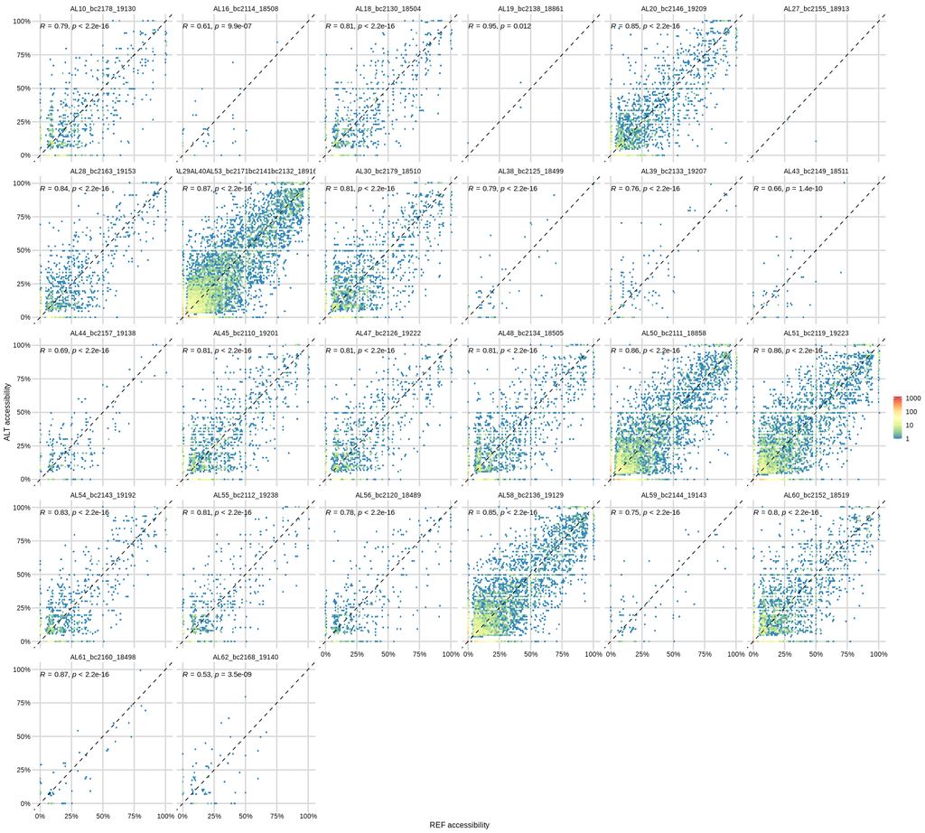

```r
show_allele_plot(cre_allele_by_sample, "LCL_hsca_cre_allele_by_sample", "ref_vs_alt",
  pair = FALSE, pooled = FALSE)
```

#### 2. Single-cCRE allele differences within each donor

Each panel is one donor, and each observation is one cCRE. The x-axis is ALT open fraction minus REF open fraction. For example, 50% ALT versus 20% REF gives +30 percentage points. The y-axis shows evidence from a two-sided Fisher exact test comparing open versus closed read counts between alleles. High observations on the right support greater ALT accessibility; high observations on the left support greater REF accessibility. BH correction is performed separately within each donor across tested cCREs.

Output: `LCL_hsca_cre_allele_by_sample_volcano.pdf`.

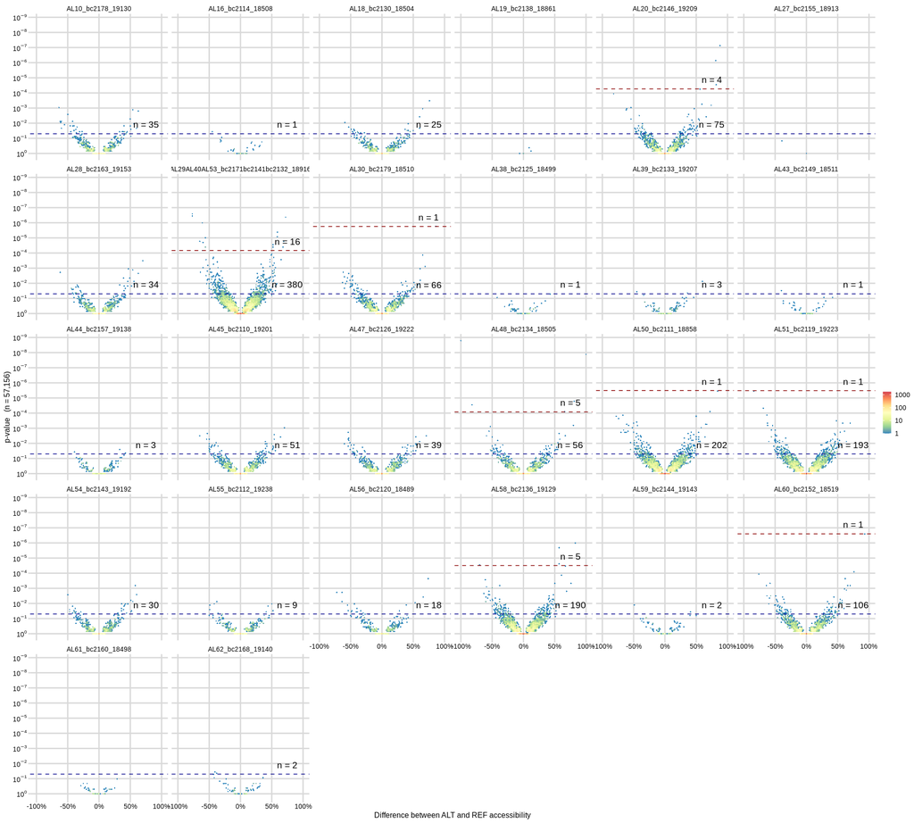

```r
show_allele_plot(cre_allele_by_sample, "LCL_hsca_cre_allele_by_sample", "volcano",
  pair = FALSE, pooled = FALSE)
```

#### 3. Pair both-open fractions within each donor

Each panel is one donor, and each observation is one cCRE pair. The x-axis is the fraction of REF reads spanning the pair on which both cCREs are open; the y-axis is the corresponding ALT fraction. The denominator includes all eligible spanning reads, including those with only one or neither cCRE open. Above the diagonal means simultaneous opening is more frequent on ALT molecules; below means it is more frequent on REF molecules.

Output: `LCL_hsca_pair_allele_by_sample_ref_vs_alt.pdf`.

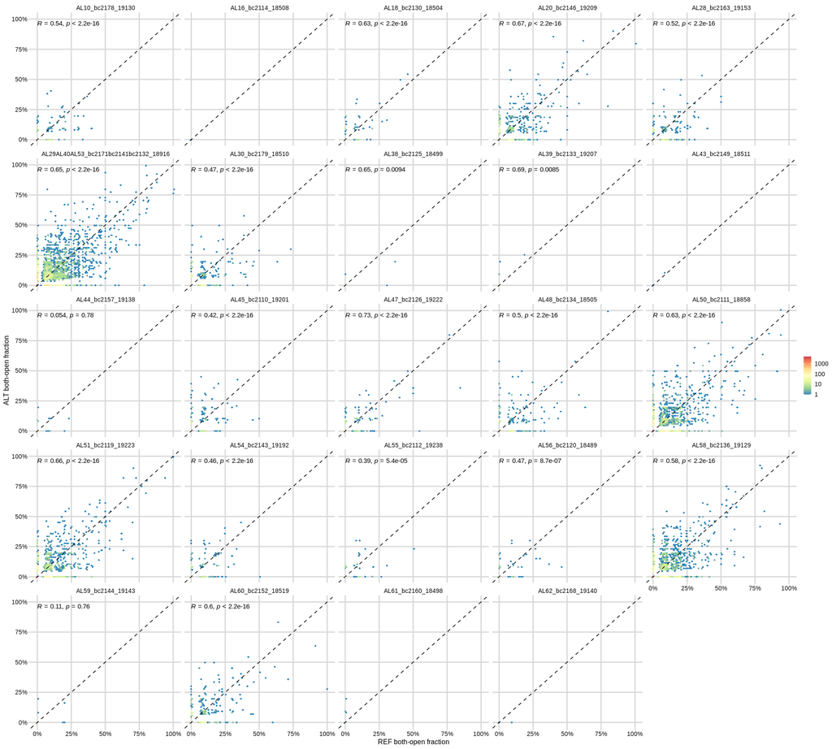

```r
show_allele_plot(pair_allele_by_sample, "LCL_hsca_pair_allele_by_sample", "ref_vs_alt",
  pair = TRUE, pooled = FALSE)
```

#### 4. Pair allele differences within each donor

Each observation is one pair in one donor. The x-axis is ALT both-open fraction minus REF both-open fraction. Fisher’s exact test compares both-open versus all other spanning reads between alleles. High observations on the right support more frequent simultaneous opening on ALT molecules; high observations on the left support REF. BH correction is performed separately within each donor across tested pairs. This tests a difference in both-open fractions, not a difference in co-accessibility strength after accounting for each cCRE’s individual accessibility: a difference can arise because one or both cCREs are individually more accessible.

Output: `LCL_hsca_pair_allele_by_sample_volcano.pdf`.

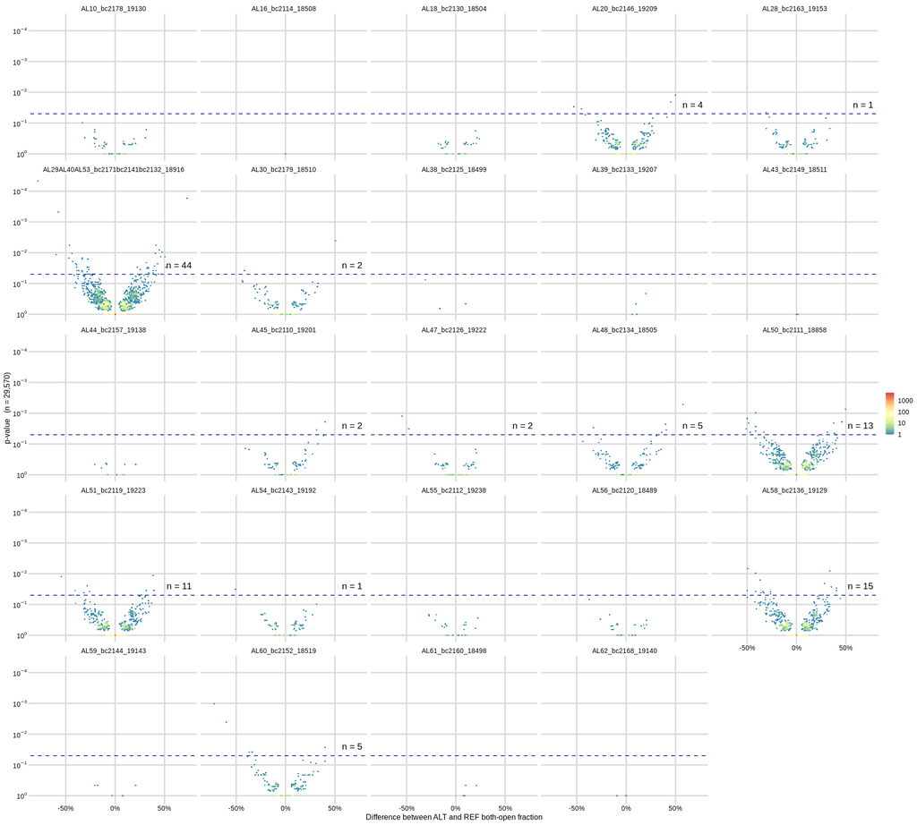

```r
show_allele_plot(pair_allele_by_sample, "LCL_hsca_pair_allele_by_sample", "volcano",
  pair = TRUE, pooled = FALSE)
```

#### 5. Single-cCRE accessibility pooled across donors

Each observation is one cCRE. Qualifying donors’ REF counts are summed together, and their ALT counts are summed together, before calculating open fractions. The x-axis shows pooled REF accessibility and the y-axis pooled ALT accessibility. Above the diagonal favors ALT; below favors REF. These are pooled read fractions, not equal-weight averages of donor fractions: donors with more qualifying reads contribute more to the corresponding allele’s fraction.

Output: `LCL_hsca_cre_allele_ref_vs_alt.pdf`.

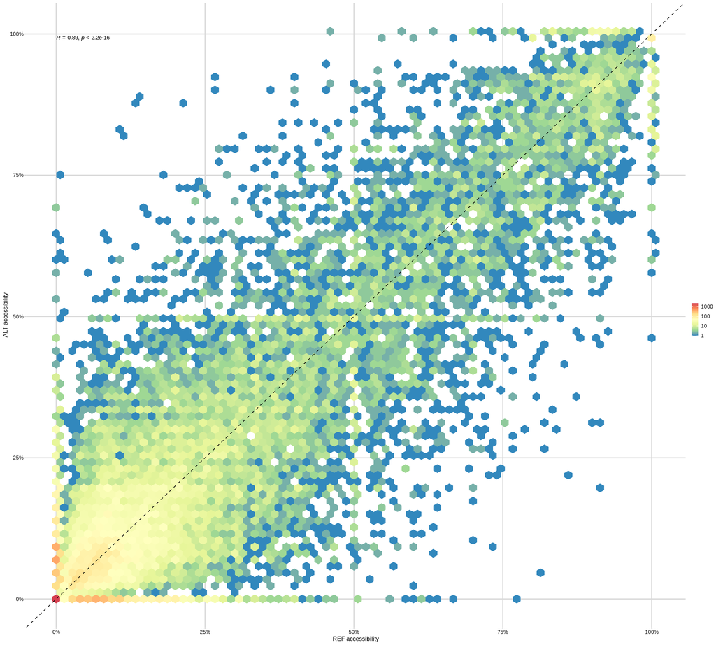

```r
show_allele_plot(cre_allele[!is.na(p_value)], "LCL_hsca_cre_allele", "ref_vs_alt",
  pair = FALSE, pooled = TRUE)
```

#### 6. Single-cCRE allele differences pooled across donors

Each observation is one cCRE. The x-axis is pooled ALT accessibility minus pooled REF accessibility; the y-axis shows Fisher-test evidence from pooled open and closed counts. BH correction is across tested cCREs. High observations on the right support greater pooled ALT accessibility; those on the left support REF. A significant pooled result supports a difference in the combined reads, but does not establish that every donor shows the same direction or that the effect is consistent across donors.

Output: `LCL_hsca_cre_allele_volcano.pdf`.

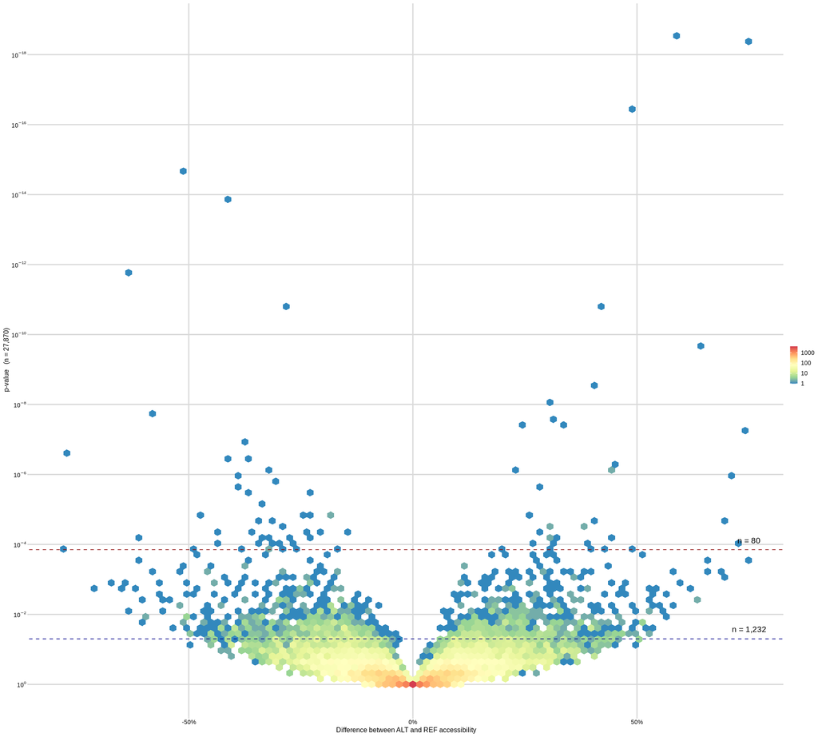

```r
show_allele_plot(cre_allele[!is.na(p_value)], "LCL_hsca_cre_allele", "volcano",
  pair = FALSE, pooled = TRUE)
```

#### 7. Pair both-open fractions pooled across donors

Each observation is one cCRE pair. The axes show pooled REF (x) and ALT (y) both-open fractions after summing qualifying donors’ counts. All eligible spanning reads enter the corresponding allele’s denominator, including reads with only one or neither cCRE open. Above the diagonal means simultaneous opening is more frequent among pooled ALT molecules; below means it is more frequent among pooled REF molecules. Donors contribute in proportion to their qualifying read counts.

Output: `LCL_hsca_pair_allele_ref_vs_alt.pdf`.

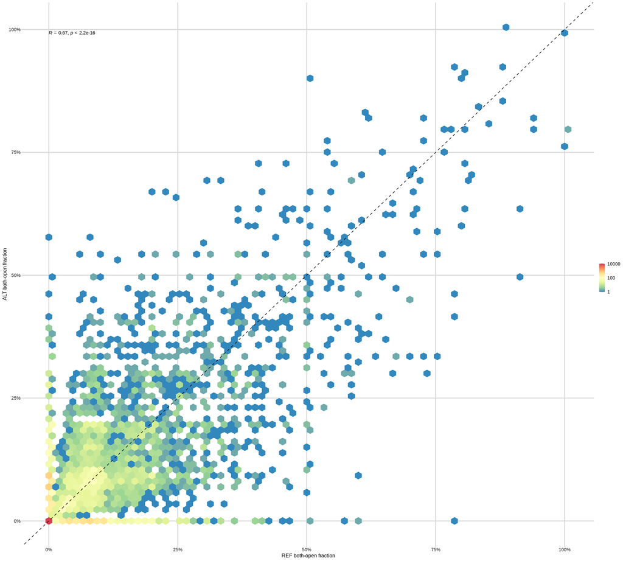

```r
show_allele_plot(pair_allele[!is.na(p_value)], "LCL_hsca_pair_allele", "ref_vs_alt",
  pair = TRUE, pooled = TRUE)
```

#### 8. Pair allele differences pooled across donors

Each observation is one pair. The x-axis is pooled ALT both-open fraction minus pooled REF both-open fraction. The y-axis shows Fisher-test evidence comparing both-open versus other spanning-read counts between alleles. BH correction is across tested pairs. High observations away from zero identify supported allele differences in simultaneous accessibility: right favors ALT and left favors REF. This does not establish a consistent effect in every donor, or an allele difference in co-accessibility strength independent of the individual cCREs’ accessibility.

Output: `LCL_hsca_pair_allele_volcano.pdf`.

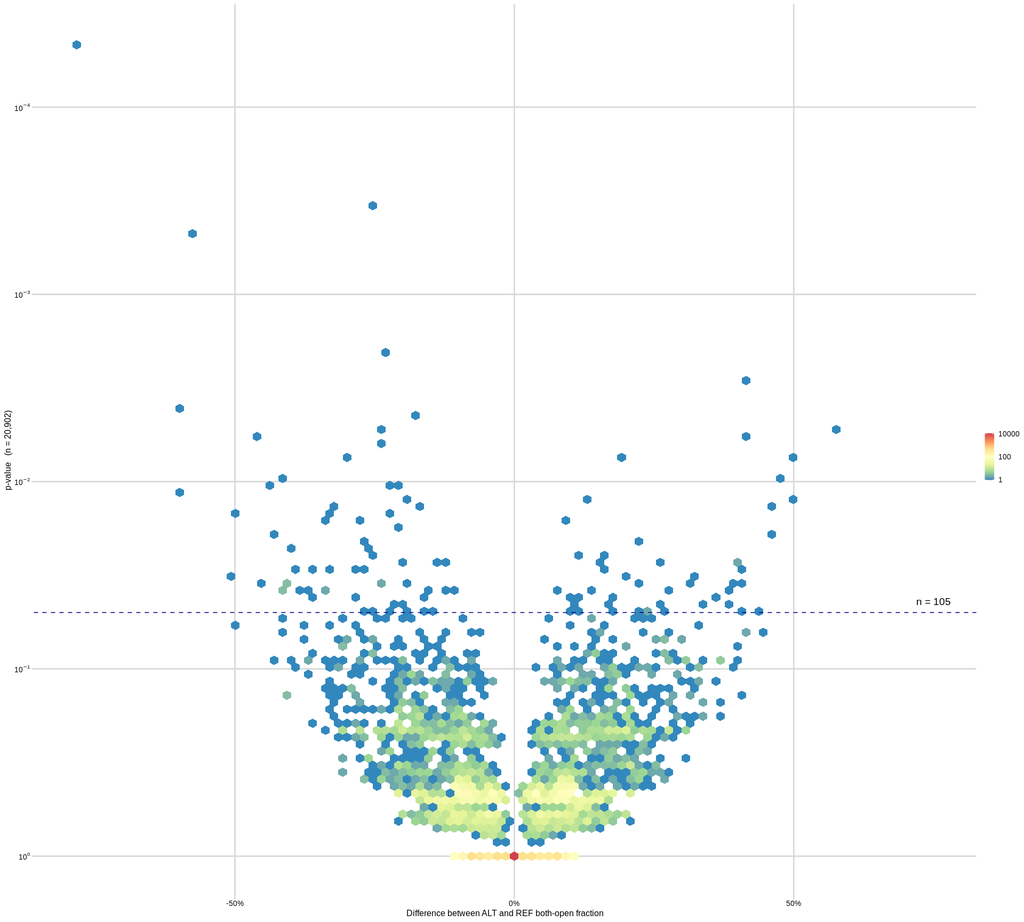

```r
show_allele_plot(pair_allele[!is.na(p_value)], "LCL_hsca_pair_allele", "volcano",
  pair = TRUE, pooled = TRUE)
```

#### Are pooled co-accessible pairs allele-skewed?

Pooled positives are `fdr < 0.05 & OR > 1 & co_access > expected_co_access` in the pooled table (all chromosomes) and the noXCI table; only autosomal pairs can be tested here Each test compares the skewed fraction of positives with the skewed fraction of the other tested pairs.

```r
positives = list(
  all_chr = pooled[fdr < fdr_cut & OR > 1 & co_access > expected_co_access, CRE_pair],
  noXCI = pooled_noxci[fdr_noXCI < fdr_cut & OR_noXCI > 1 & co_access_noXCI > expected_co_access_noXCI, CRE_pair])

# A pair is allele-skewed if a within-donor or pooled REF/ALT test is significant.
pair_flags = rbind(
  pair_allele_by_sample[, .(CRE_pair, skewed = status != "ns")],
  pair_allele[!is.na(p_value), .(CRE_pair, skewed = fdr < fdr_cut)]
)[, .(allele_skewed = any(skewed)), by = CRE_pair]

enrichment = rbindlist(lapply(names(positives), function(set) {
  rbindlist(lapply("allele_skewed", function(test) {
    d = pair_flags[!is.na(get(test)), .(positive = CRE_pair %in% positives[[set]], skewed = get(test))]
    ft = fisher.test(table(factor(d$positive, c(TRUE, FALSE)), factor(d$skewed, c(TRUE, FALSE))))
    data.table(positive_set = set, test = test, n_tested = nrow(d), n_positive_tested = sum(d$positive),
               n_skewed = sum(d$skewed), n_positive_skewed = sum(d$positive & d$skewed),
               frac_skewed_positive = mean(d$skewed[d$positive]), frac_skewed_other = mean(d$skewed[!d$positive]),
               odds_ratio = unname(ft$estimate), p_value = ft$p.value)
  }))
}))
fwrite(enrichment, file.path(tables_dir, "LCL_hsca_pooled_positive_enrichment.tsv"), sep = "\t")
knitr::kable(enrichment, digits = 4)
```

| positive_set | test | n_tested | n_positive_tested | n_skewed | n_positive_skewed | frac_skewed_positive | frac_skewed_other | odds_ratio | p_value |
| --- | --- | --- | --- | --- | --- | --- | --- | --- | --- |
| all_chr | allele_skewed | 20902 | 657 | 0 | 0 | 0 | 0 | 0 | 1 |
| noXCI | allele_skewed | 20902 | 640 | 0 | 0 | 0 | 0 | 0 | 1 |

#### Co-accessible pairs with pooled allele selectivity, ranked by p-value

These lists use the **pooled REF/ALT pair test**. Co-accessibility still requires pooled co-accessibility FDR < 0.05, OR > 1, and observed both-open counts above expectation. Within that set, raw allele p < 0.05 identifies **exploratory candidates**; allele BH FDR < 0.05 identifies the corrected discoveries. The allele BH values are retained from the original test across all tested autosomal pairs; they are **not recalculated after selecting co-accessible pairs**. Every list is sorted by raw allele p-value, with CRE_pair breaking ties. Coordinates are BED (0-based, end-exclusive). The `difference_pp` column is ALT minus REF both-open fraction, in percentage points.

```r
pair_annotation = pooled[, .(CRE_pair, chrom, cre1_start, cre1_end, cre2_start, cre2_end,
  gene_names, CRE_pair_labels, coaccess_OR = OR, coaccess_fdr = fdr,
  coaccess_p_value = pval, n_shared_reads, co_access, expected_co_access)]
stopifnot(!anyDuplicated(pair_annotation$CRE_pair), !anyDuplicated(pair_allele$CRE_pair))
ranked_pair_alleles = merge(copy(pair_allele[!is.na(p_value)]), pair_annotation,
  by = "CRE_pair", all.x = TRUE, sort = FALSE)
stopifnot(!anyNA(ranked_pair_alleles$chrom))
setnames(ranked_pair_alleles, c("p_value", "fdr"), c("allele_p_value", "allele_bh_fdr"))
ranked_pair_alleles[, `:=`(
  coaccessible = CRE_pair %in% positives$all_chr,
  allele_nominal = allele_p_value < fdr_cut,
  allele_bh_significant = allele_bh_fdr < fdr_cut,
  ref_n = ref_open + ref_closed,
  alt_n = alt_open + alt_closed,
  difference_percentage_points = 100 * diff)]
setorder(ranked_pair_alleles, allele_p_value, CRE_pair)
rank_pair_list = function(d) {
  d = copy(d)
  d[, rank := seq_len(.N)]
  setcolorder(d, c("rank", setdiff(names(d), "rank")))
  d[]
}
coaccessible_allele_nominal = rank_pair_list(ranked_pair_alleles[coaccessible & allele_nominal])
coaccessible_allele_bh = rank_pair_list(ranked_pair_alleles[coaccessible & allele_bh_significant])
all_pair_allele_bh = rank_pair_list(ranked_pair_alleles[allele_bh_significant == TRUE])
fwrite(coaccessible_allele_nominal,
  file.path(tables_dir, "LCL_hsca_coaccessible_pair_allele_nominal_ranked.tsv"), sep = "\t")
fwrite(coaccessible_allele_bh,
  file.path(tables_dir, "LCL_hsca_coaccessible_pair_allele_BH_ranked.tsv"), sep = "\t")
fwrite(all_pair_allele_bh,
  file.path(tables_dir, "LCL_hsca_all_pair_allele_BH_ranked.tsv"), sep = "\t")
knitr::kable(data.table(
  group = c("Co-accessible pairs with an allele test", "Raw allele p < 0.05 (exploratory)",
            "Allele BH FDR < 0.05 among co-accessible pairs", "Allele BH FDR < 0.05 among all pairs"),
  n_pairs = c(sum(ranked_pair_alleles$coaccessible), nrow(coaccessible_allele_nominal),
              nrow(coaccessible_allele_bh), nrow(all_pair_allele_bh))))
```

| group | n_pairs |
| --- | --- |
| Co-accessible pairs with an allele test | 657 |
| Raw allele p < 0.05 (exploratory) | 17 |
| Allele BH FDR < 0.05 among co-accessible pairs | 0 |
| Allele BH FDR < 0.05 among all pairs | 0 |

```r
show_ranked_pairs = function(d) {
  knitr::kable(d[, .(rank, CRE_pair, gene_names,
    CRE1_interval = paste0(chrom, ":", cre1_start, "-", cre1_end),
    CRE2_interval = paste0(chrom, ":", cre2_start, "-", cre2_end), variant_id,
    REF_both_open = paste0(ref_open, "/", ref_n),
    ALT_both_open = paste0(alt_open, "/", alt_n),
    difference_pp = round(difference_percentage_points, 2),
    allele_p = formatC(allele_p_value, format = "e", digits = 3),
    allele_BH_FDR = formatC(allele_bh_fdr, format = "e", digits = 3),
    coaccess_FDR = formatC(coaccess_fdr, format = "e", digits = 3),
    coaccessible, n_samples_both_alleles)])
}
```

**BH-significant allele-selective co-accessible pairs**

```r
show_ranked_pairs(coaccessible_allele_bh)
```

| rank | CRE_pair | gene_names | CRE1_interval | CRE2_interval | variant_id | REF_both_open | ALT_both_open | difference_pp | allele_p | allele_BH_FDR | coaccess_FDR | coaccessible | n_samples_both_alleles |
| --- | --- | --- | --- | --- | --- | --- | --- | --- | --- | --- | --- | --- | --- |

# significantly allele-skewed cCREs that belong to significant co-accessible pairs

Which allele-skewed cCREs participate in at least one significantly positively co-accessible pair?

CLASP1 was selected from significantly positively co-accessible pairs with an individually allele-skewed cCRE (pooled cCRE BH FDR < 0.05, October 27 allele results) whose focal SNV is a significant GTEx v8 LCL cis-eQTL (`/project/spott/cshan/annotations/LCL_public_data/GTEx_Analysis_v8_eQTL/`).

This selection does not require the pair’s REF/ALT test to be significant. The pair’s selected focal SNP is used for the molecule figures; here it is the same SNV as the individual-cCRE test. The CLASP1 label is the GTEx eQTL gene, not a proven target.

| Locus | Individually skewed cCRE | Partner cCRE | Focal SNV | GTEx LCL eQTL |
| --- | --- | --- | --- | --- |
| CLASP1 | `EH38E2029449.dELS` | `EH38E3368841.dELS` | chr2:121599032 C>T | CLASP1, ALT slope -0.51, p = 2.6e-6 |

## CLASP1: single-molecule view of both cCREs

| allele_group | molecules | samples |
| --- | --- | --- |
| REF-C | 82 | 11 |
| ALT-T | 81 | 9 |

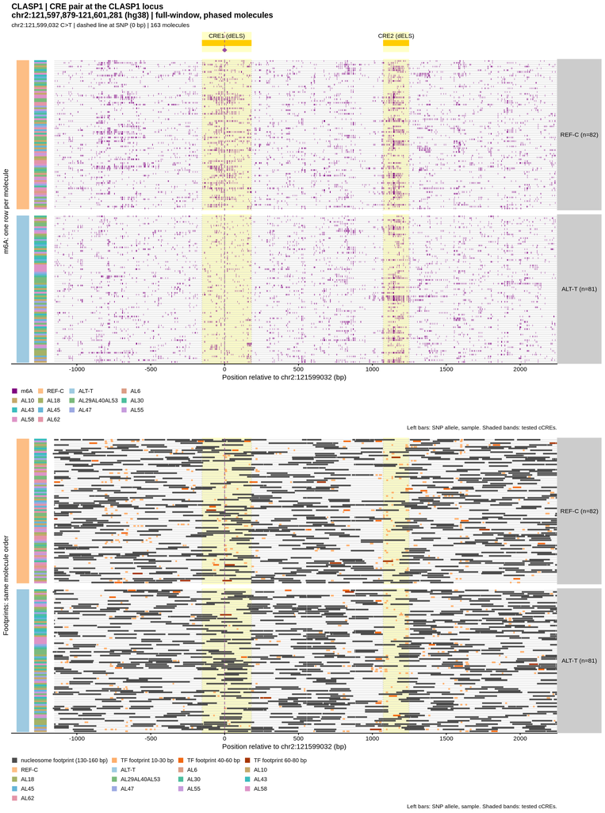

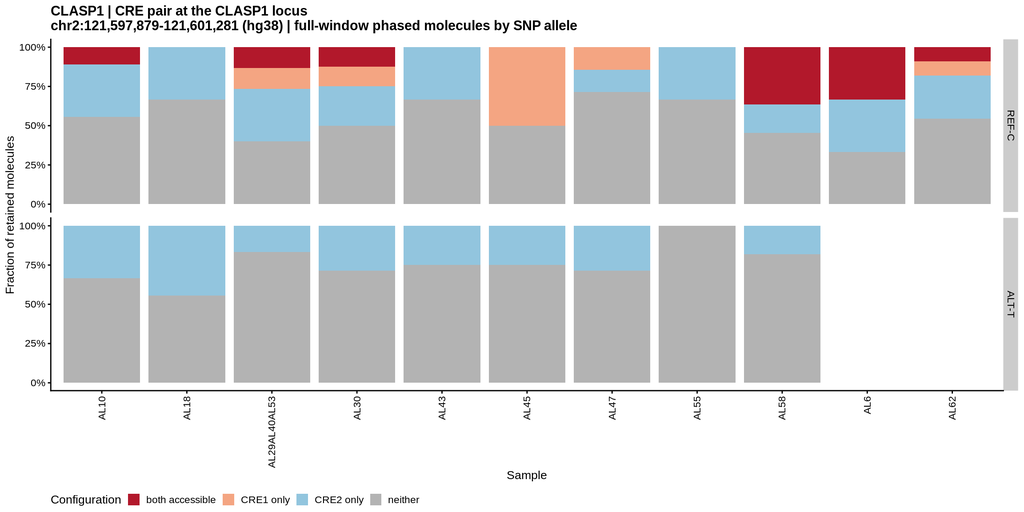

#### CLASP1: phased-molecule m6A heatmaps and Manhattan/Leiden clustering

| cluster | molecules | samples | in_phased_plot | zero_m6a_molecules |
| --- | --- | --- | --- | --- |
| cluster1 | 65 | 11 | 54 | 0 |
| cluster2 | 54 | 11 | 48 | 0 |
| cluster3 | 39 | 10 | 31 | 0 |
| cluster4 | 33 | 10 | 25 | 0 |
| cluster5 | 5 | 5 | 5 | 0 |

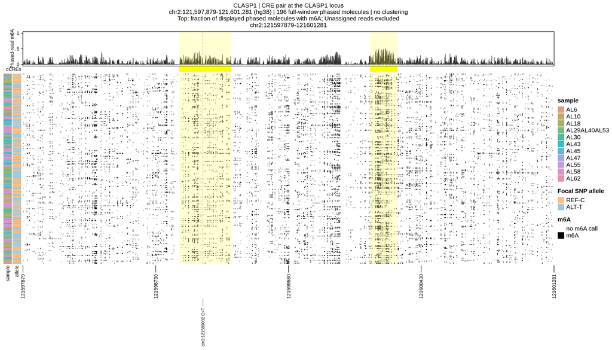

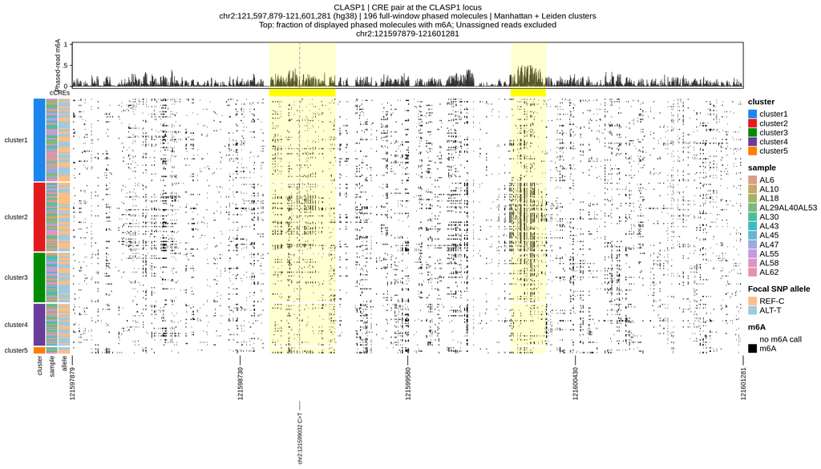

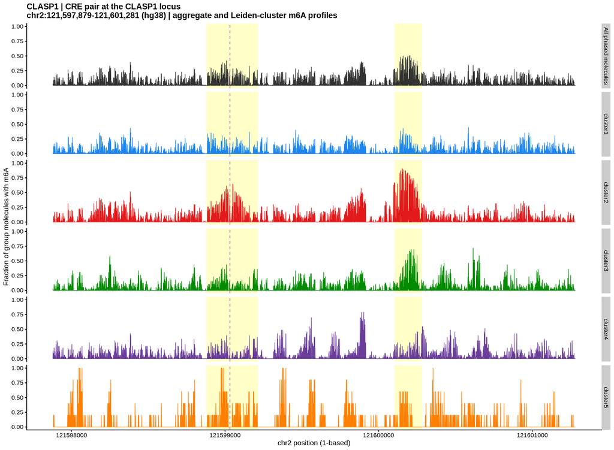

### domain, loops and CTCF annotation of selected CRE pairs

| gene | focal_snv | group | molecules | samples | donors |
| --- | --- | --- | --- | --- | --- |
| CLASP1 | chr2:121599032:C:T | CC | 19 | 2 | 2 |
| CLASP1 | chr2:121599032:C:T | CT: C reads | 82 | 11 | 11 |
| CLASP1 | chr2:121599032:C:T | CT: T reads | 100 | 10 | 10 |
| CLASP1 | chr2:121599032:C:T | TT | 173 | 13 | 13 |

| sample | CLASP1 |
| --- | --- |
| AL10 | het (11/16) |
| AL16 | hom_alt (0/10) |
| AL18 | het (5/13) |
| AL19 | hom_alt (0/13) |
| AL20 | hom_alt (0/37) |
| AL27 | hom_alt (7/6) |
| AL28 | het (0/35) |
| AL29AL40AL53 | het (26/20) |
| AL30 | het (11/19) |
| AL38 | hom_alt (0/18) |
| AL39 | hom_alt (0/18) |
| AL43 | het (9/6) |
| AL44 | hom_alt (0/22) |
| AL45 | het (9/9) |
| AL47 | het (15/12) |
| AL48 | hom_alt (0/25) |
| AL50 | hom_alt (0/40) |
| AL51 | hom_alt (0/35) |
| AL54 | hom_alt (27/0) |
| AL55 | het (13/11) |
| AL56 | hom_ref (9/19) |
| AL58 | het (22/19) |
| AL59 | hom_ref (13/0) |
| AL6 | het (4/3) |
| AL60 | hom_alt (0/25) |
| AL61 | hom_alt (0/13) |
| AL62 | het (13/3) |

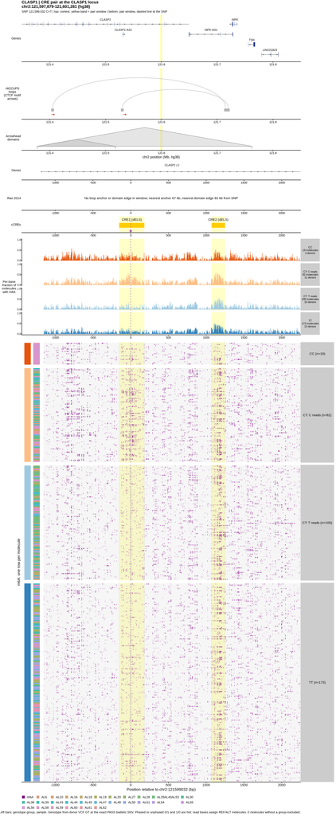

## co-accessible pairs with allele-specific chromatin accessibility

Significant positive co-accessibility: co-accessibility BH FDR <0.05, OR >1, and observed both-open counts above expectation. Nominal allele-selective accessibility: pooled REF/ALT Fisher raw p <0.05, without requiring allele BH FDR <0.05.

### SLFN5: single-molecule view of both cCREs

| allele_group | molecules | samples |
| --- | --- | --- |
| REF-G | 45 | 9 |
| ALT-A | 33 | 8 |

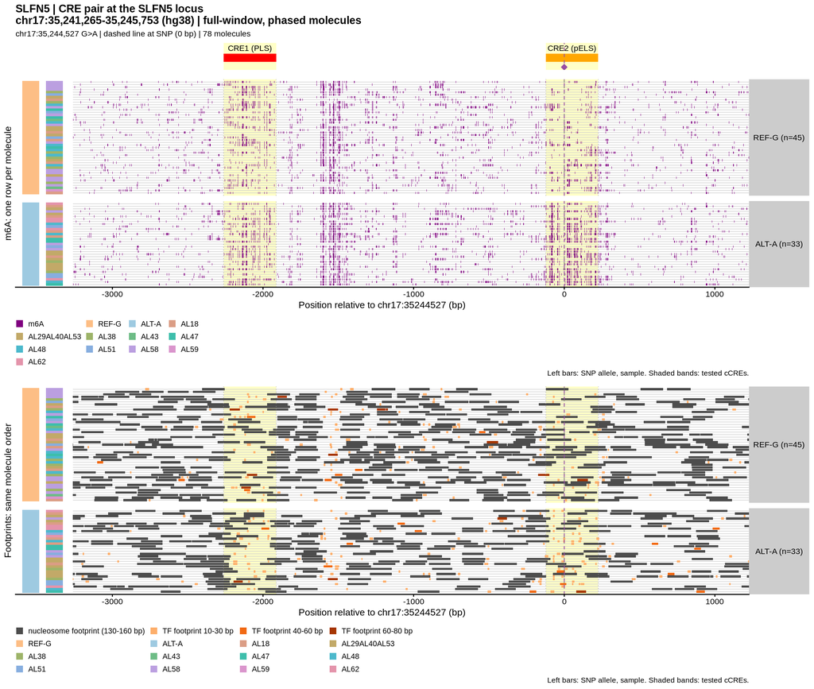

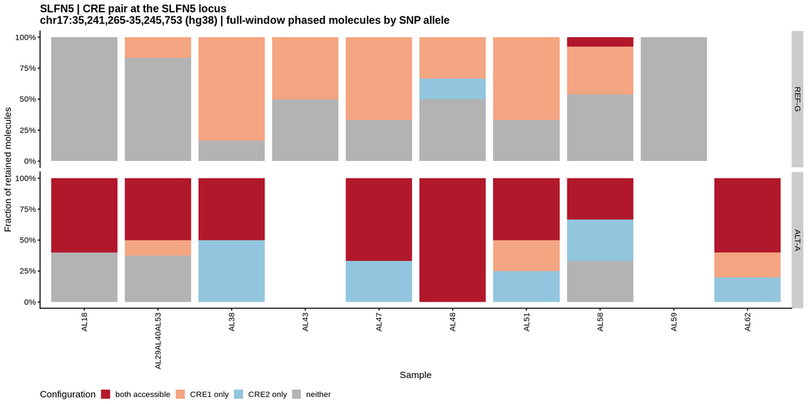

### SLFN5: phased-molecule m6A heatmaps and Manhattan/Leiden clustering

| cluster | molecules | samples | in_phased_plot | zero_m6a_molecules |
| --- | --- | --- | --- | --- |
| cluster1 | 60 | 10 | 29 | 0 |
| cluster2 | 47 | 10 | 24 | 0 |
| cluster3 | 37 | 9 | 19 | 0 |
| cluster4 | 8 | 4 | 6 | 0 |

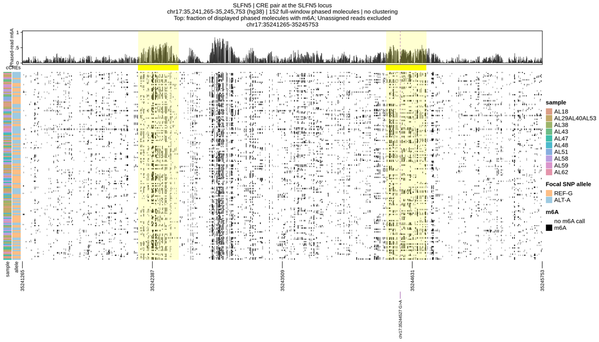

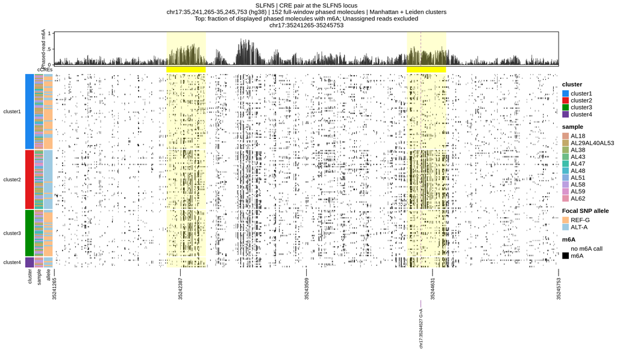

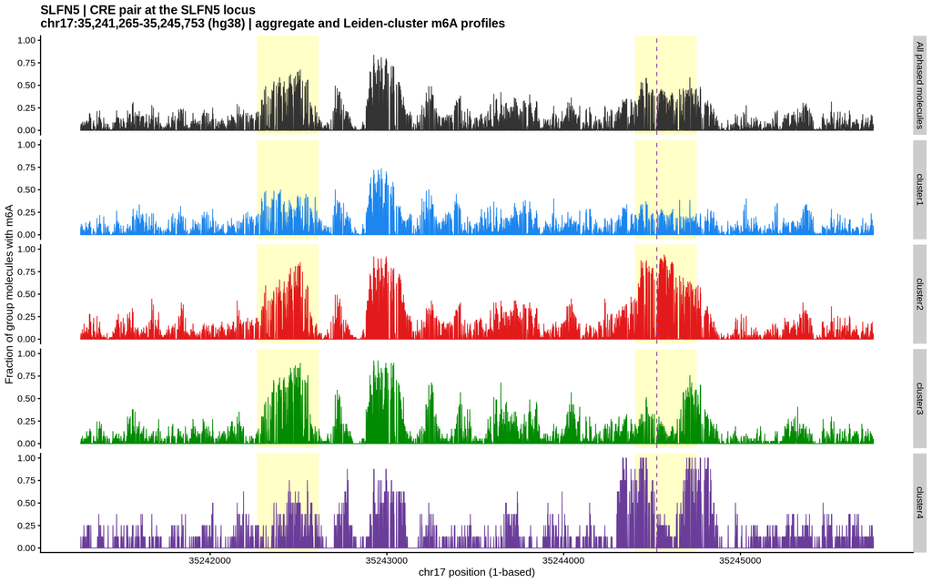

## SLFN5: gene, domain and CTCF context

The same locus-context and molecule plotting method is used for SLFN5.

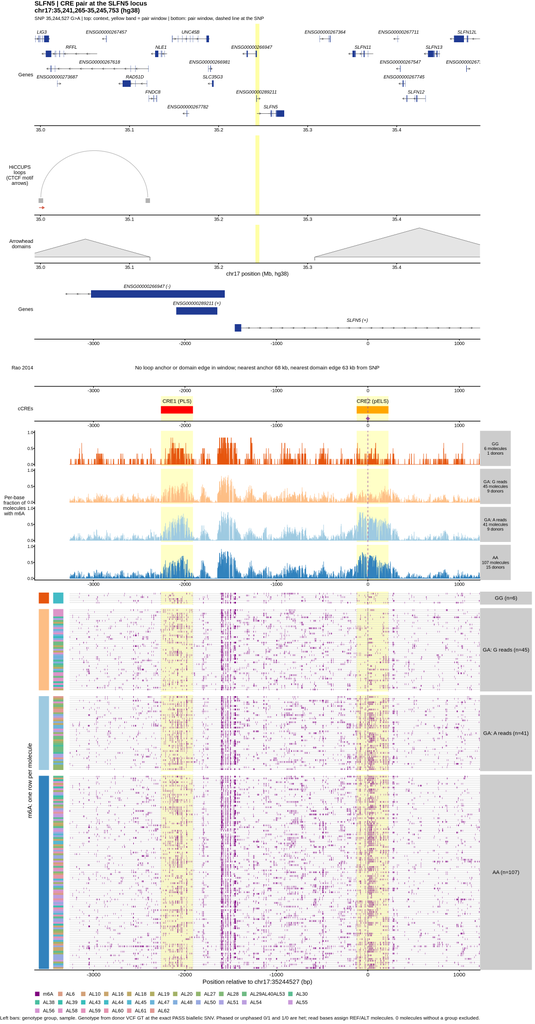

# GTEx eQTL variants in co-accessible pairs

Which cCREs in significant positive co-accessible pairs contain the lead variant of a GTEx v8 LCL (`Cells_EBV-transformed_lymphocytes`) cis-eGene?

- Lead variant: the most significant variant GTEx reports for an eGene (`egenes` file, qval <= 0.05)
- only co-accessible pairs that survive BH correction, i.e. co-accessibility BH FDR < 0.05 (`fdr` in the 27-sample pooled table, BH across all genome-wide pairs with >= 20 fibers spanning both cCREs), OR > 1, and observed both-open counts above expectation, autosomes only

Allele-specific m6A: reads are labelled REF or ALT by the base they carry at the GTEx lead variant (`pair_genotype_calls()`). Only donors with a heterozygous VCF GT (0/1 or 1/0, phased or unphased) at the exact PASS biallelic SNV contribute, matching the statistical tests’ genotype rule. Read counts do not determine genotype. `n_het_samples` counts VCF-het donors even if no usable fibers are available; fiber counts report the actual m6A coverage.

- `fiber_m6a_proportions()`: scores each het-sample fiber that spans the whole cCRE: its m6A calls / the cCRE positions with at least one m6A call among those fibers (not divided by A/T bases). `ref_m6a_prop` and `alt_m6a_prop` ggregate each allele’s fibers: total m6A calls / (fibers x positions).

```r
gtex_egenes = fread(file.path("/project/spott/cshan/annotations/LCL_public_data/GTEx_Analysis_v8_eQTL",
  "Cells_EBV-transformed_lymphocytes.v8.egenes.txt.gz"),
  select = c("gene_id", "gene_name", "variant_id", "pval_nominal", "qval"))[qval <= fdr_cut]
gtex_egenes[, `:=`(chrom = sub("_.*$", "", variant_id),
  pos = as.integer(sub("^[^_]+_([0-9]+)_.*$", "\\1", variant_id)))]

# BH-significant positive co-accessible pairs (fdr = BH-adjusted), autosomes only; one row per cCRE and partner
sig_autosomal = pooled[!is.na(fdr) & fdr < fdr_cut & OR > 1 & co_access > expected_co_access &
  !chrom %in% c("chrX", "chrY")]
pair_sides = rbind(
  sig_autosomal[, .(CRE_ID = CRE1, chrom, start = cre1_start, end = cre1_end, partner = CRE2, dist, OR, fdr)],
  sig_autosomal[, .(CRE_ID = CRE2, chrom, start = cre2_start, end = cre2_end, partner = CRE1, dist, OR, fdr)])
sig_cres = unique(pair_sides[, .(CRE_ID, chrom, start, end)])
lead_in_cre = merge(sig_cres, gtex_egenes, by = "chrom", allow.cartesian = TRUE)[start < pos & pos <= end]

cre_partners = pair_sides[order(fdr), .(n_sig_pairs = .N, partners = paste(sprintf("%s (%s bp, OR %.1f, BH FDR %.2g)",
  sub("^EH38D[0-9]+\\.", "", partner), dist, OR, fdr), collapse = "; ")), by = CRE_ID]
coaccess_lead_eqtl = cre_partners[lead_in_cre[, .(CRE_ID, chrom, start, end, lead_variant = variant_id,
  egene = gene_name, gene_id, eqtl_p = pval_nominal)], on = "CRE_ID"][order(eqtl_p)]

# Aggregated m6A proportion per allele of the lead variant, het samples' full-span fibers
hsca_manifest = hsca_sample_manifest(params)
allele_m6a = function(cre_id, chrom, start, end, lead_variant) {
  snv = strsplit(sub("_b38$", "", lead_variant), "_", fixed = TRUE)[[1]]
  stopifnot(length(snv) == 4L, nchar(snv[3]) == 1L, nchar(snv[4]) == 1L)
  region = data.frame(region_id = cre_id, chr = chrom, start = start, end = end,
    focal_pos = as.integer(snv[2]), ref = snv[3], alt = snv[4])
  genotypes = pair_genotype_calls(region, hsca_manifest, "/project/spott/cshan/envs/Jupyter-notebook/bin/python3",
    file.path(params$code_root, "co-accessibility/LCL/hsca/hsca_functions.py"))
  het = genotypes$calls[genotype == "het", sample_name]
  out = data.table(n_het_samples = length(het), ref_m6a_prop = NA_real_, alt_m6a_prop = NA_real_,
                   n_ref_fibers = 0L, n_alt_fibers = 0L)
  if (!length(het)) return(out)
  fibers = genotypes$alleles[sample_name %in% het, .(sample_name, original_RID = read_name, allele)]
  scored = fiber_m6a_proportions(as.data.frame(hsca_manifest[sample_name %in% het]), region, fibers)$fibers[
    status == "retained"]
  agg = scored[, .(prop = sum(n_m6a_calls) / sum(n_positions), n = .N), by = allele]
  out[, `:=`(ref_m6a_prop = agg[allele == "ref", prop][1], alt_m6a_prop = agg[allele == "alt", prop][1],
             n_ref_fibers = scored[allele == "ref", .N], n_alt_fibers = scored[allele == "alt", .N])]
  out
}
lead_cres = unique(coaccess_lead_eqtl[, .(CRE_ID, chrom, start, end, lead_variant)])
lead_cres = cbind(lead_cres, rbindlist(Map(allele_m6a, lead_cres$CRE_ID, lead_cres$chrom,
  lead_cres$start, lead_cres$end, lead_cres$lead_variant)))
coaccess_lead_eqtl = lead_cres[coaccess_lead_eqtl, on = .(CRE_ID, chrom, start, end, lead_variant)][order(eqtl_p)]
setcolorder(coaccess_lead_eqtl, c("CRE_ID", "chrom", "start", "end", "lead_variant", "egene", "gene_id", "eqtl_p"))
fwrite(coaccess_lead_eqtl, file.path(tables_dir, "LCL_hsca_coaccess_cre_gtex_lead_eqtl.tsv"), sep = "\t")

knitr::kable(data.table(
  set = c("Autosomal BH-significant co-accessible pairs", "cCREs in those pairs",
          "cCREs containing an eGene lead variant", "eGenes"),
  n = c(nrow(sig_autosomal), nrow(sig_cres), uniqueN(coaccess_lead_eqtl$CRE_ID), uniqueN(coaccess_lead_eqtl$gene_id))))
```

| set | n |
| --- | --- |
| Autosomal BH-significant co-accessible pairs | 2157 |
| cCREs in those pairs | 3723 |
| cCREs containing an eGene lead variant | 15 |
| eGenes | 17 |

```r
knitr::kable(coaccess_lead_eqtl[, .(cCRE = sub("^EH38D[0-9]+\\.", "", CRE_ID),
  location = paste0(chrom, ":", start, "-", end), lead_variant, egene,
  eqtl_p = formatC(eqtl_p, format = "e", digits = 1), n_het_samples,
  ref_m6a_prop = round(ref_m6a_prop, 3), alt_m6a_prop = round(alt_m6a_prop, 3), n_ref_fibers, n_alt_fibers,
  n_sig_pairs, partners)])
```

| cCRE | location | lead_variant | egene | eqtl_p | n_het_samples | ref_m6a_prop | alt_m6a_prop | n_ref_fibers | n_alt_fibers | n_sig_pairs | partners |
| --- | --- | --- | --- | --- | --- | --- | --- | --- | --- | --- | --- |
| EH38E4160235.pELS | chr17:35244404-35244753 | chr17_35244527_G_A_b38 | SLFN5 | 4.4e-53 | 11 | 0.128 | 0.365 | 121 | 141 | 3 | EH38E3219256.pELS (585 bp, OR 2.9, BH FDR 0.0077); EH38E3219251.PLS (1790 bp, OR 2.7, BH FDR 0.015); EH38E3219253.PLS (1218 bp, OR 2.4, BH FDR 0.039) |
| EH38E1317631.PLS | chr1:9943188-9943529 | chr1_9943262_G_A_b38 | LZIC | 6.9e-29 | 7 | 0.400 | 0.523 | 101 | 62 | 1 | EH38E2785168.pELS (540 bp, OR 4.5, BH FDR 0.014) |
| EH38E3256544.dELS | chr18:9710769-9711109 | chr18_9710890_G_A_b38 | RAB31 | 5.6e-17 | 13 | 0.230 | 0.158 | 127 | 157 | 1 | EH38E3256545.dELS (515 bp, OR 5.3, BH FDR 0.00027) |
| EH38E3589686.pELS | chr4:76012146-76012436 | chr4_76012292_A_G_b38 | CXCL10 | 3.3e-09 | 5 | 0.222 | 0.145 | 42 | 34 | 1 | EH38E3589687.dELS (1089 bp, OR 4.3, BH FDR 0.00046) |
| EH38E3448106.pELS | chr20:63010360-63010710 | chr20_63010496_G_A_b38 | LINC01056 | 6.4e-09 | 1 | 0.567 | 0.063 | 5 | 2 | 1 | EH38E3448104.PLS (915 bp, OR 5.8, BH FDR 0.00053) |
| EH38E3203640.dELS | chr17:2392604-2392942 | chr17_2392720_T_C_b38 | MNT | 6.6e-09 | 12 | 0.514 | 0.430 | 108 | 61 | 1 | EH38E3203643.dELS (785 bp, OR 6.4, BH FDR 0.041) |
| EH38E1971415.dELS | chr2:9099359-9099629 | chr2_9099506_C_T_b38 | MBOAT2 | 9.9e-09 | 11 | 0.261 | 0.104 | 129 | 113 | 1 | EH38E3323428.dELS (874 bp, OR 4.6, BH FDR 2e-05) |
| EH38E3448106.pELS | chr20:63010360-63010710 | chr20_63010496_G_A_b38 | LINC00029 | 5.4e-08 | 1 | 0.567 | 0.063 | 5 | 2 | 1 | EH38E3448104.PLS (915 bp, OR 5.8, BH FDR 0.00053) |
| EH38E3263561.pELS | chr18:35466333-35466683 | chr18_35466558_G_A_b38 | INO80C | 3.5e-07 | 12 | 0.115 | 0.177 | 149 | 97 | 1 | EH38E3263563.pELS (977 bp, OR 4.9, BH FDR 0.00019) |
| EH38E3263561.pELS | chr18:35466333-35466683 | chr18_35466558_G_A_b38 | RP11-322E11.5 | 4.0e-07 | 12 | 0.115 | 0.177 | 149 | 97 | 1 | EH38E3263563.pELS (977 bp, OR 4.9, BH FDR 0.00019) |
| EH38E3065725.pELS | chr13:48591617-48591965 | chr13_48591739_G_A_b38 | LINC00462 | 7.7e-07 | 12 | 0.091 | 0.177 | 168 | 127 | 1 | EH38E3065723.PLS (707 bp, OR 17.9, BH FDR 9.8e-10) |
| EH38E3260466.PLS | chr18:23992535-23992873 | chr18_23992873_C_G_b38 | RP11-403A21.1 | 1.6e-06 | 15 | 0.125 | 0.112 | 186 | 179 | 1 | EH38E1904552.dELS (5117 bp, OR 6.0, BH FDR 0.005) |
| EH38E2440164.dELS | chr6:2898265-2898491 | chr6_2898362_A_G_b38 | SERPINB9 | 2.3e-06 | 3 | 0.137 | 0.300 | 26 | 61 | 1 | EH38E3686339.PLS (4709 bp, OR 3.2, BH FDR 0.015) |
| EH38E4281046.pELS | chr22:31230561-31230910 | chr22_31230660_C_G_b38 | LIMK2 | 2.7e-06 | 0 | NA | NA | 0 | 0 | 1 | EH38E2158464.pELS (503 bp, OR 4.9, BH FDR 0.0085) |
| EH38E2474436.pELS | chr6:54307533-54307879 | chr6_54307667_A_C_b38 | TINAG | 2.9e-06 | 0 | NA | NA | 0 | 0 | 2 | EH38E3713426.dELS (3217 bp, OR 21.1, BH FDR 4.6e-06); EH38E3713428.dELS (3717 bp, OR 9.8, BH FDR 0.00041) |
| EH38E4203506.PLS | chr19:58150638-58150986 | chr19_58150868_C_T_b38 | ZNF329 | 6.7e-06 | 1 | 0.328 | 0.260 | 17 | 7 | 1 | EH38E3318927.pELS (4034 bp, OR 7.4, BH FDR 1.3e-08) |
| EH38E2833566.dELS | chr1:116738774-116739121 | chr1_116738860_T_A_b38 | PTGFRN | 1.2e-05 | 12 | 0.214 | 0.217 | 110 | 93 | 1 | EH38E1379871.dELS (641 bp, OR 3.0, BH FDR 0.0019) |

Two lead-eQTL pairs are plotted with the same molecule, clustering and domain/CTCF methods as SLFN5. In both, the pair’s focal SNV used to split molecules is the GTEx lead variant.

| Locus | eQTL cCRE | Partner cCRE | Lead variant |
| --- | --- | --- | --- |
| LZIC | `EH38E1317631.PLS` | `EH38E2785168.pELS` | chr1:9943262 G>A |
| LINC00462 | `EH38E3065725.pELS` | `EH38E3065723.PLS` | chr13:48591739 G>A |

## LZIC: single-molecule view of both cCREs

| allele_group | molecules | samples |
| --- | --- | --- |
| REF-G | 33 | 6 |
| ALT-A | 32 | 5 |

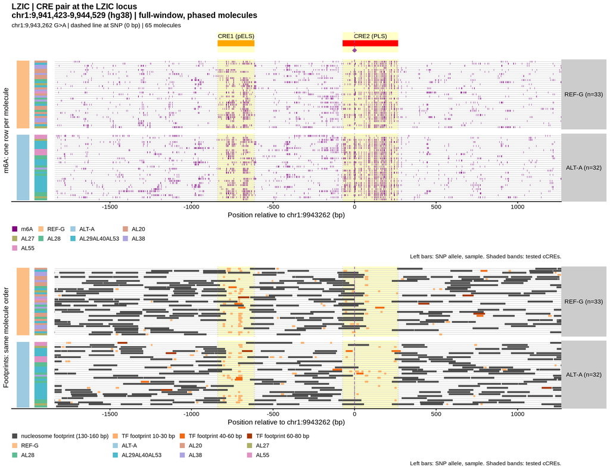

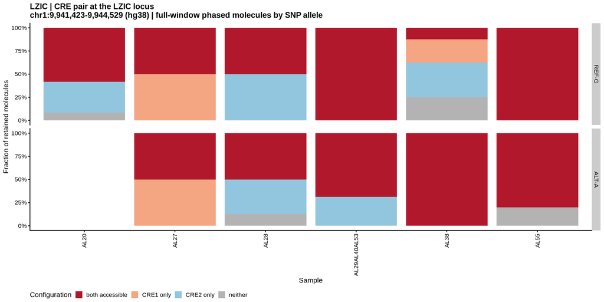

### LZIC: phased-molecule m6A heatmaps and Manhattan/Leiden clustering

| cluster | molecules | samples | in_phased_plot | zero_m6a_molecules |
| --- | --- | --- | --- | --- |
| cluster1 | 33 | 6 | 17 | 0 |
| cluster2 | 32 | 6 | 22 | 0 |
| cluster3 | 24 | 6 | 12 | 0 |
| cluster4 | 15 | 5 | 9 | 0 |
| cluster5 | 9 | 5 | 5 | 0 |

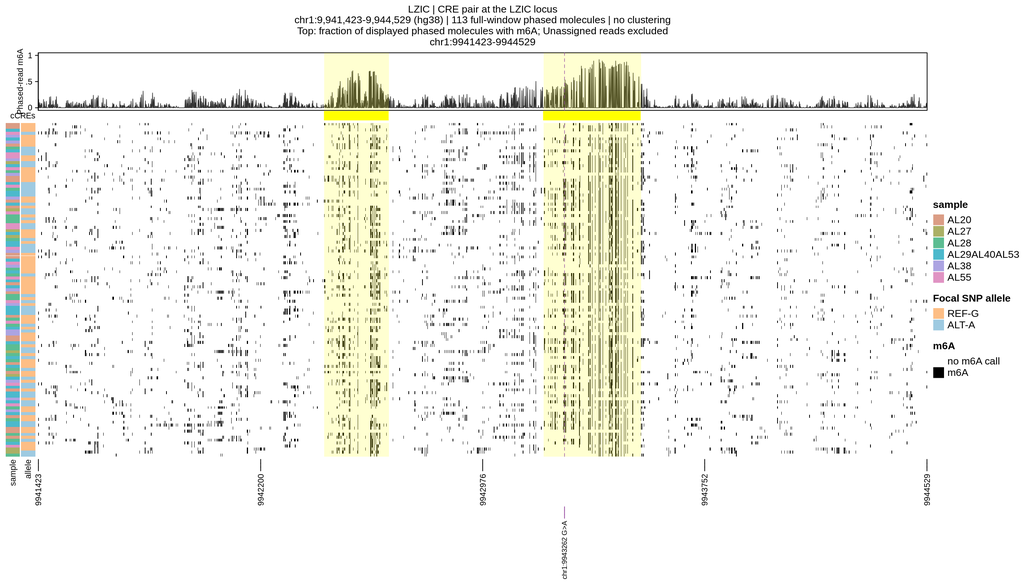

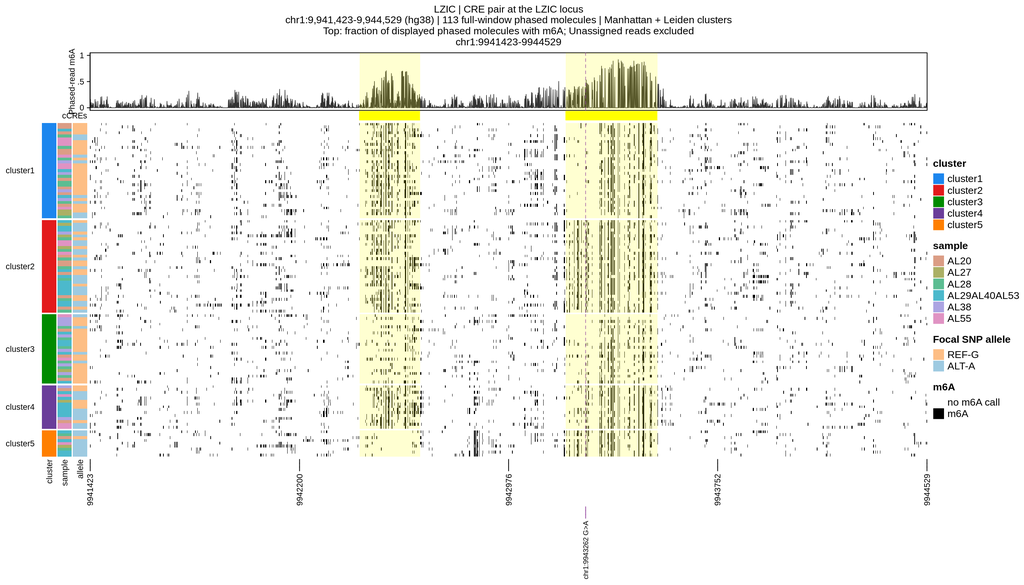

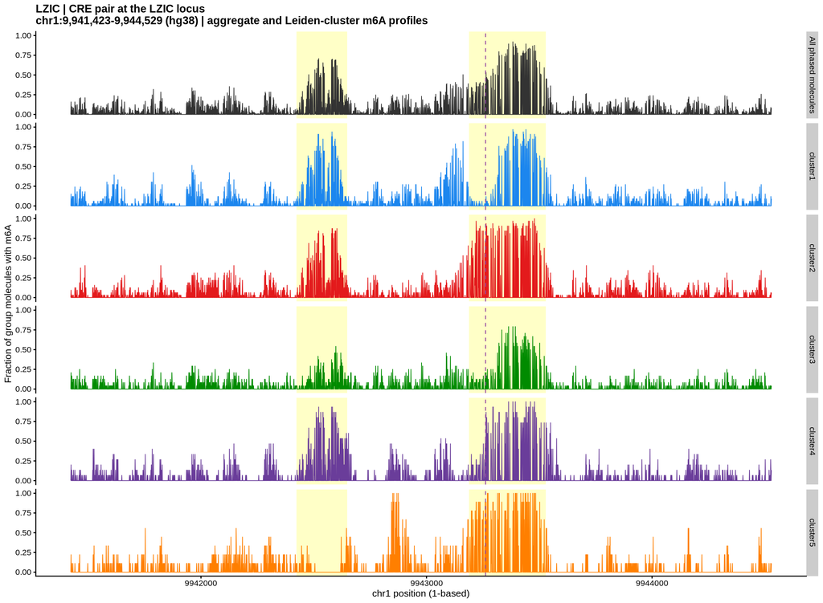

## LINC00462: single-molecule view of both cCREs

| allele_group | molecules | samples |
| --- | --- | --- |
| REF-G | 62 | 9 |
| ALT-A | 52 | 10 |

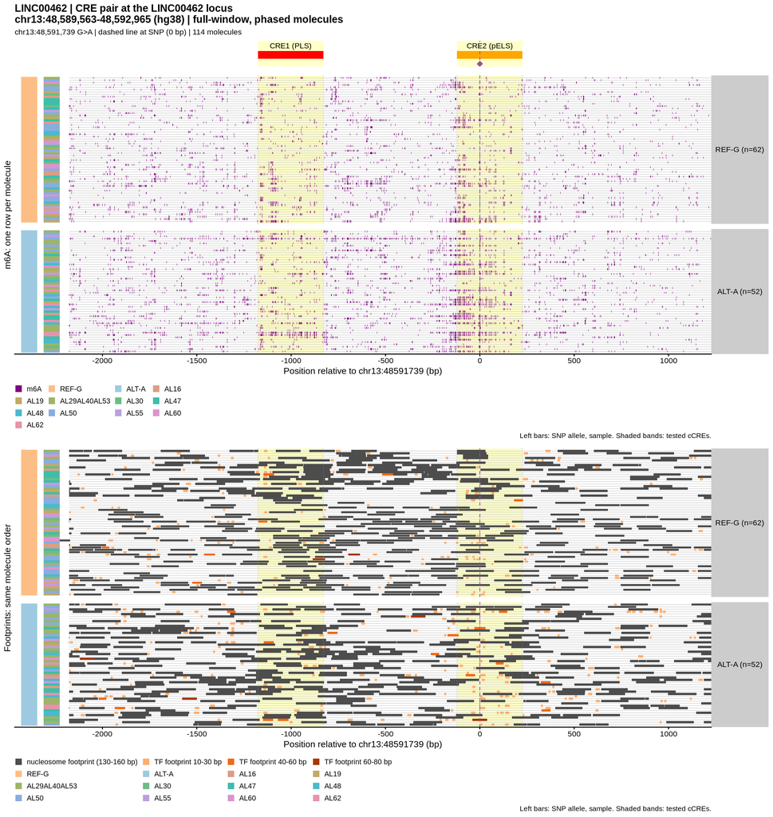

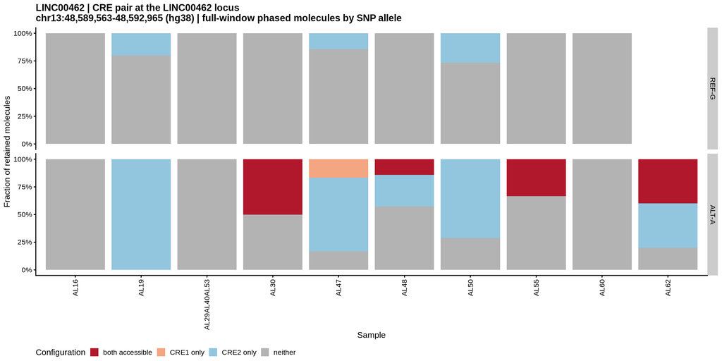

### LINC00462: phased-molecule m6A heatmaps and Manhattan/Leiden clustering

| cluster | molecules | samples | in_phased_plot | zero_m6a_molecules |
| --- | --- | --- | --- | --- |
| cluster1 | 57 | 10 | 37 | 0 |
| cluster2 | 48 | 11 | 26 | 0 |
| cluster3 | 43 | 10 | 25 | 0 |
| cluster4 | 23 | 10 | 16 | 0 |
| cluster5 | 20 | 7 | 10 | 0 |

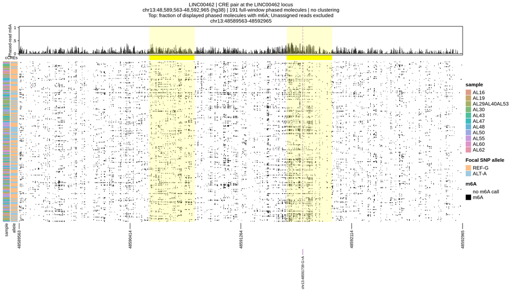

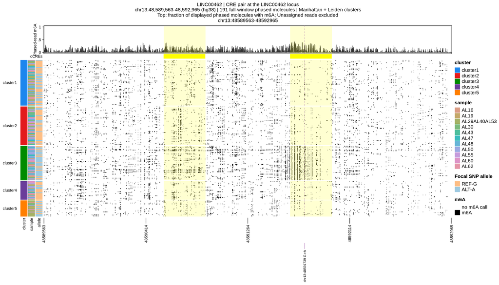

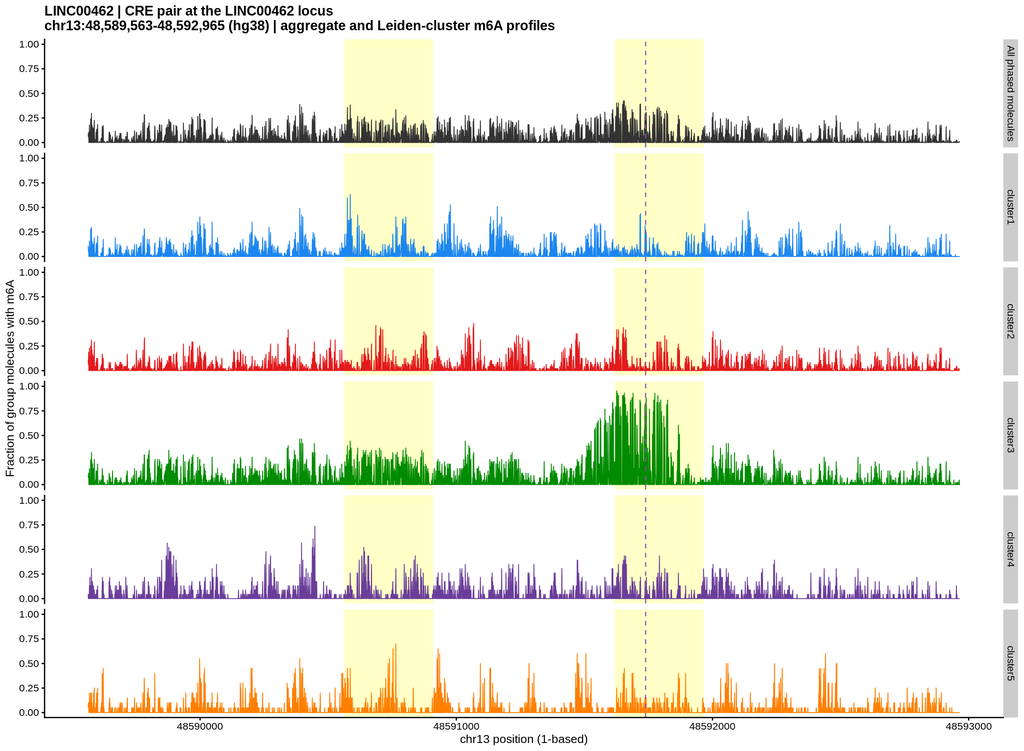

## LZIC and LINC00462: gene, domain and CTCF context

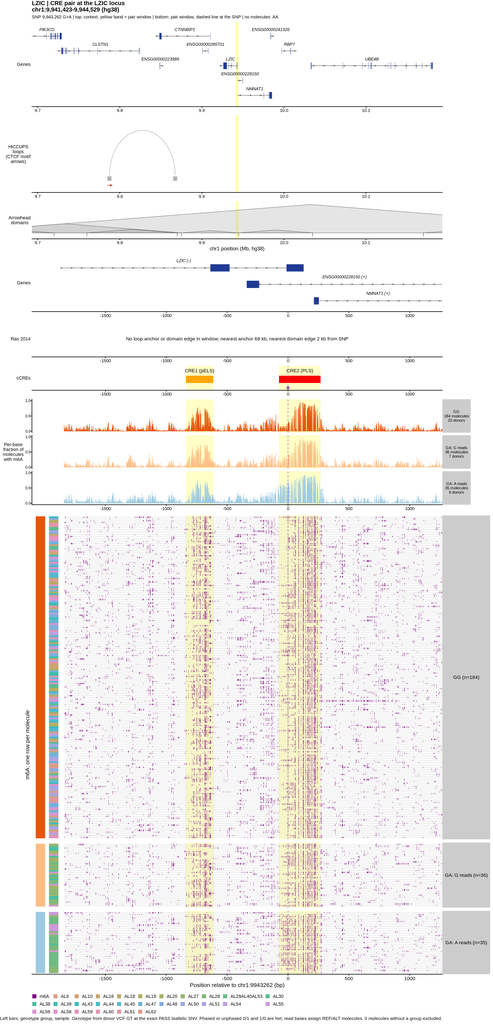

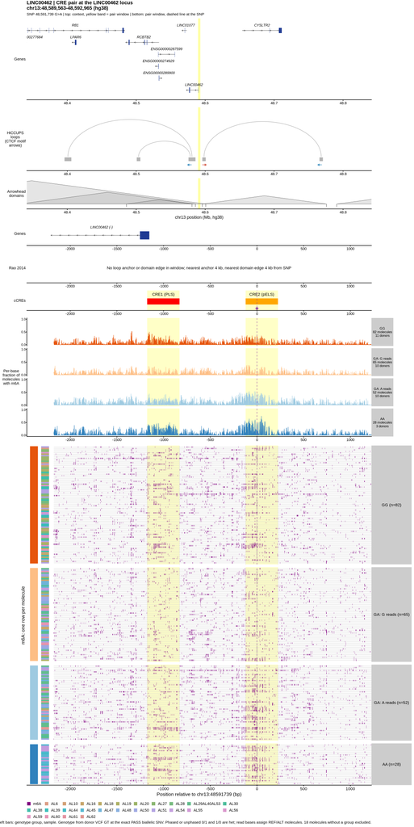